# week 14

sophia

2024-05-21

```r
library(knitr)
knitr::opts_chunk$set(echo = T)
```

# AI Prompt

## Preset

You are an assistant to data visualization. You use R in tidyverse style for assistance. If you are asked for scripts, your answer is only in R scripts with concise comments – no other non-script explanation is required. The first line of your code chunk must be a comment line. Its format is `# {{summary_title}} -----` where `{{summary_title}}` is your short summary of the assisted task. Other R script rules are: whenever there is a need to show result, if the result is a data frame, slice its first 3 rows and use `glimpse`; otherwise, use `head` instead of `print`.

For plotting, always use `theme_minimal` when it is not a map. If it uses map, use `theme_void` instead. Except `theme_void`, the x-axis line should be a solid black. If creating a new plot, always create a plot object and show it. If adding layers to an existing plot, always show the plot after adding each layer. A plot should always have a title, and a subtitle to show the unit of y axis. In addition, there should be a footnote showing data source.

For map data, always use `geom_sf` for plotting unless impossible. When simplifying simple features, always use `st_simplify` with `preserveTopology = TRUE` and `dTolerance =1`.

When requesting data from OpenStreetMap, always use `osmdata` package. When requesting data from OpenStreetMap, always use `osmdata` package. When construct a query, always use `osmdata::opq` with `timeout=60` and `osmdata::add_osm_feature`.

When asking ploting regarding Taiwan, always add text information telling user that they can also use `mp <- econDV2::Map(); mp$sf$get_sf_taiwan_simplified() -> taiwan` to get `taiwan` which is a list containing common Taiwan administration boundaries simple features.

The first code you give should always `library(tidyverse)`. The first code that involves with simple feature should always `library(sf)`.

If you understand your role, say it – no need to show any code at this time.

## Tasks Prompt

Here is a data frame ‘companies’ like this: $ year 2000, 2002, 2004, 2006, 2008, 2010, 2012, 2014, 2016, 2018, 2020,… $ company “Microsoft”, “Microsoft”, “Microsoft”, “Microsoft”, “Microsoft”, … $ market_cap 5.100400e+11, 2.838210e+11, 2.954774e+11, 2.937800e+11, 1.801852e… Code a line chart following material design UI.

# Trillion-dollar tech company market cap

```r
# Trillion-dollar tech company market cap -----
library(tidyverse)
library(sf)
# Data frame 'companies'
companies <- tribble(
  ~year, ~company, ~market_cap,
  2000, "Microsoft", 510040000000,
  2002, "Microsoft", 283821040000,
  2004, "Microsoft", 295477440000,
  2006, "Microsoft", 293780000000,
  2008, "Microsoft", 180185200000,
  2010, "Microsoft", 219134720000,
  2012, "Microsoft", 249272320000,
  2014, "Microsoft", 355376000000,
  2016, "Microsoft", 482198400000,
  2018, "Microsoft", 859371520000,
  2020, "Microsoft", 1631568000000,
  2000, "Amazon", 16545600000,
  2002, "Amazon", 6679200000,
  2004, "Amazon", 17517600000,
  2006, "Amazon", 19166400000,
  2008, "Amazon", 31764800000,
  2010, "Amazon", 74334400000,
  2012, "Amazon", 115655200000,
  2014, "Amazon", 150788800000,
  2016, "Amazon", 356789600000,
  2018, "Amazon", 737632000000,
  2020, "Amazon", 1592000000000,
  2004, "Alphabet", 51151200000,
  2006, "Alphabet", 117914400000,
  2008, "Alphabet", 115070400000,
  2010, "Alphabet", 193416000000,
  2012, "Alphabet", 249995200000,
  2014, "Alphabet", 345599200000,
  2016, "Alphabet", 546762400000,
  2018, "Alphabet", 766757600000,
  2020, "Alphabet", 1190000000000,
  2012, "Facebook", 63804800000,
  2014, "Facebook", 213555200000,
  2016, "Facebook", 368966400000,
  2018, "Facebook", 424764800000,
  2020, "Facebook", 792000000000,
  2012, "Apple", 556624000000,
  2014, "Apple", 642630400000,
  2016, "Apple", 586038400000,
  2018, "Apple", 851358400000,
  2020, "Apple", 2312120000000
)
view(companies)
companies %>%
  mutate(year = as.integer(year)) %>%
  glimpse()
```

```
## Rows: 41
## Columns: 3
## $ year       <int> 2000, 2002, 2004, 2006, 2008, 2010, 2012, 2014, 2016, 2018,…
## $ company    <chr> "Microsoft", "Microsoft", "Microsoft", "Microsoft", "Micros…
## $ market_cap <dbl> 5.100400e+11, 2.838210e+11, 2.954774e+11, 2.937800e+11, 1.8…
```

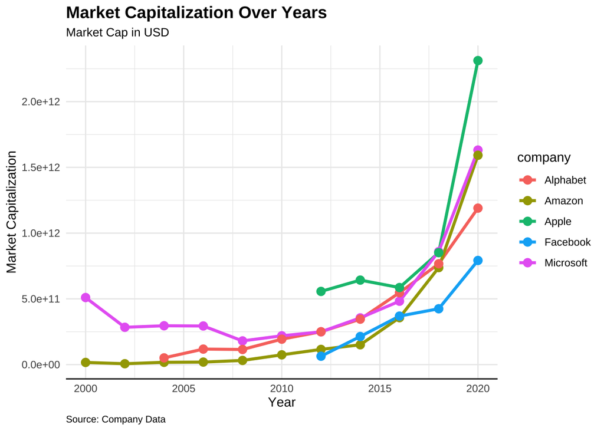

```r
# Plotting the line chart
line_chart <- ggplot(companies, aes(x = year, y = market_cap, color = company)) +
  geom_line(linewidth = 1.2) +
  geom_point(size = 3) +
  labs(
    title = "Market Capitalization Over Years",
    subtitle = "Market Cap in USD",
    x = "Year",
    y = "Market Capitalization",
    caption = "Source: Company Data"
  ) +
  theme_minimal() +
  theme(
    axis.line.x = element_line(color = "black"),
    plot.title = element_text(size = 14, face = "bold"),
    plot.subtitle = element_text(size = 10),
    plot.caption = element_text(size = 8, hjust = 0)
  )

line_chart
```

# Practice at home